# Data Analysis 2: Bivariate Analysis and Hypothesis Testing

SKPM20: Quantitative Methods 2026

nils.holmberg@iko.lu.se

## Course literature

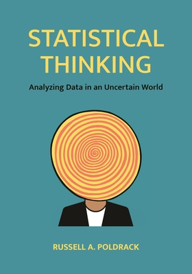

Poldrack (2023)

[figure not shown]

Field (2022)

[figure not shown]

Van de Ven (2007)

## Open science methods

- **Replicability**: Python enables reproducible research with shareable scripts.
- **Transparency**: Open-source code makes analyses fully visible.
- **Collaboration**: Supports teamwork via GitHub and Jupyter Notebooks.
- **Open Source**: Free and community-driven for open science. 🚀

[figure not shown]

## AI use in academic work

- OK: brainstorm ideas, do research
- OK: generate project materials
- OK: data analysis, statistics tools
- Not OK: copy-paste text to your exam
- Not OK: generate fake empirical data
- Not OK: upload content you dont own
- Not OK: upload data with personal info
- https://gemini.google.com/

## Lecture overview

- `Recap, computer lab 1`
- Histograms, corrections
- Save dataset to file
- `Bivariate analysis`
- Compare means
- Categorical variables
- Continuous variables
- `Hypothesis testing`
- Null hypothesis (NHST)
- Probability distributions
- Effect size, power
- `Intro, computer lab 2`
- Dependent variable
- Independent variables

Recap, Computer Lab 1

## Data analysis project, insights

- Download sample [dataset](https://github.com/cca-cce/osm-comm/raw/refs/heads/main/csv/cod-260120.xlsx) and analyze model
- `Perform descriptive statistics and data transformations`
- Perform bivariate analyses and hypothesis testing
- Perform multivariate analysis, multiple regression

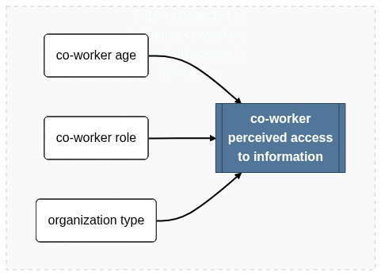

## Age histogram (new data file)

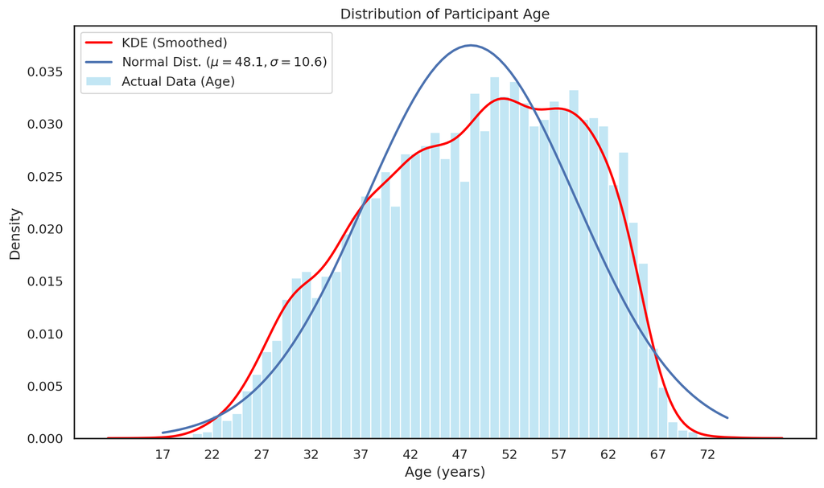

Bivariate Analysis  
and  
Hypothesis Testing

## Penguins dataset

- `species` (nominal)
- `island` (nominal)
- `bill_length_mm` (cont.)
- `bill_depth_mm` (cont.)
- `flipper_length_mm` (cont.)
- `body_mass_g` (cont.)
- `sex` (binary)

```python
# Load the dataset
path = "../../csv/penguins.tsv"
dfp = pd.read_csv(path, sep="\t")

print(dfp["species"].value_counts(dropna=False))
```

```
species
Adelie       152
Gentoo       124
Chinstrap     68
Name: count, dtype: int64
```

## Theoretical model

- Download sample [dataset](https://github.com/cca-cce/osm-comm/raw/refs/heads/main/csv/penguins.tsv) and analyze model
- Perform descriptive statistics and data transformations
- `Perform bivariate analyses and hypothesis testing`
- Perform multivariate analysis, multiple regression

[output not shown]

## Bivariate Analysis

- Explore relationships like bill length and body mass
- Use scatterplots for two continuous measures
- Use color to show species differences
- Check correlation and possible nonlinearity
- Look for clusters and outliers across species

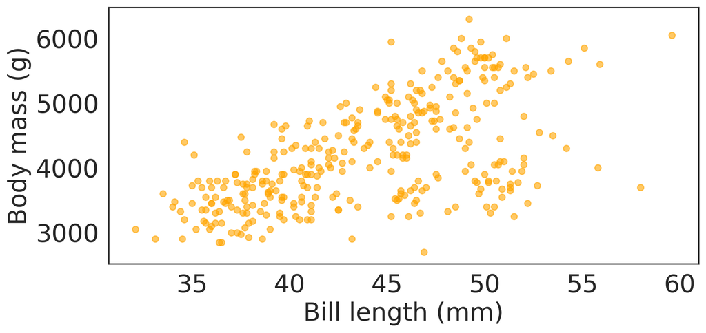

## Comparing Two Means

- Compare group averages (e.g., female vs male body mass)
- Use two-sample t-test with Welch correction
- Visualize overlap before testing
- Report group means and confidence intervals
- Consider practical significance alongside p-values

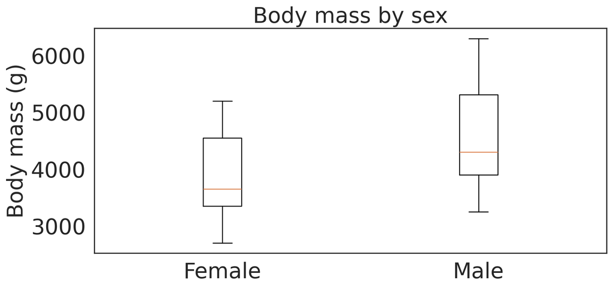

## Hypothesis Testing

- Compare means across groups (e.g., gender gaps)
- Use t-tests or nonparametric alternatives
- Emphasize effect sizes, not only p-values
- Check assumptions and sample sizes
- Interpret results in social context

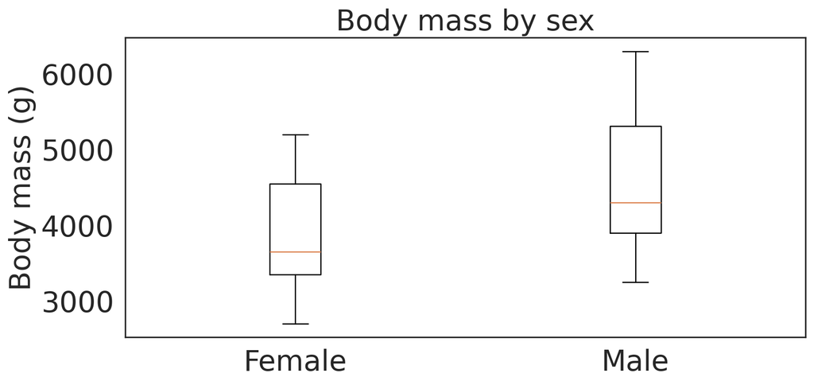

## Null Hypothesis Testing Overview

- NHST compares observed data to a null model
- The null model generates a reference distribution
- We ask: how unusual is our result under the null?
- Results depend on both effect size and sample size
- Visualization helps interpret evidence and uncertainty

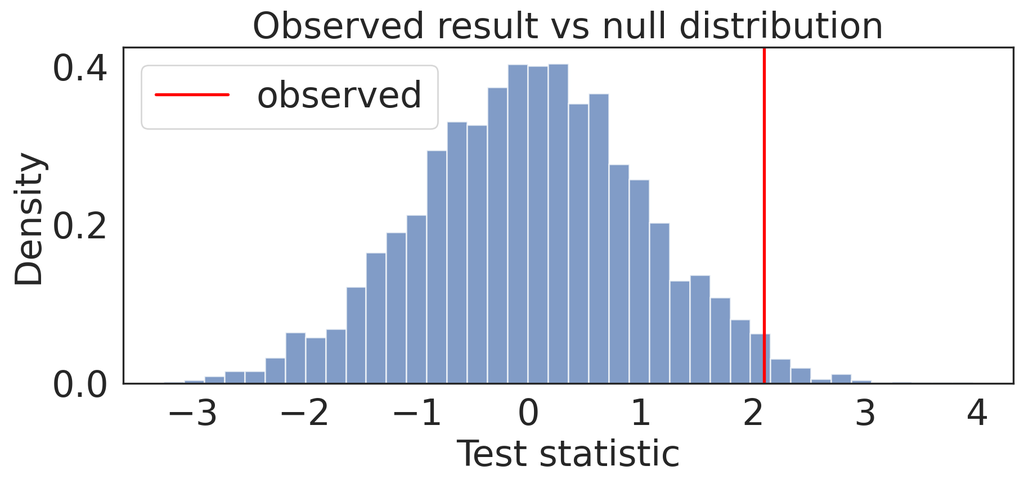

## Formulating Hypotheses

- Step 1: define a clear research hypothesis
- Step 2: specify null and alternative hypotheses
- Directional vs two-sided alternatives matter
- Hypotheses guide the test statistic and decision rule
- Clear hypotheses prevent post-hoc reinterpretation

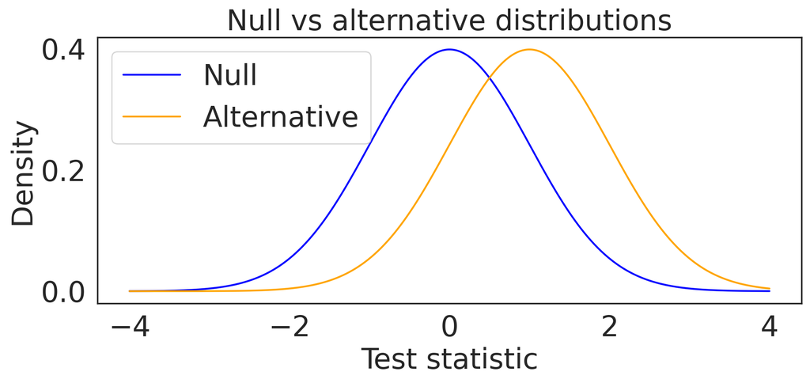

## Explore Empirical Distributions

- Collect data relevant to the hypothesis
- Choose a statistic that captures group differences
- Example: penguin body mass difference by sex
- Visualizing groups clarifies overlap and variability
- The test statistic summarizes this comparison

[figure not shown]

## Effect Size

- P-value: Probability that the result is due to random chance
- Effect Size: Numerical magnitude of the relationship’s actual strength
- Sample Size: p-values depend on sample size; effect size does not
- Scale: 0.2 is small, 0.5 is medium, and 0.8 is large

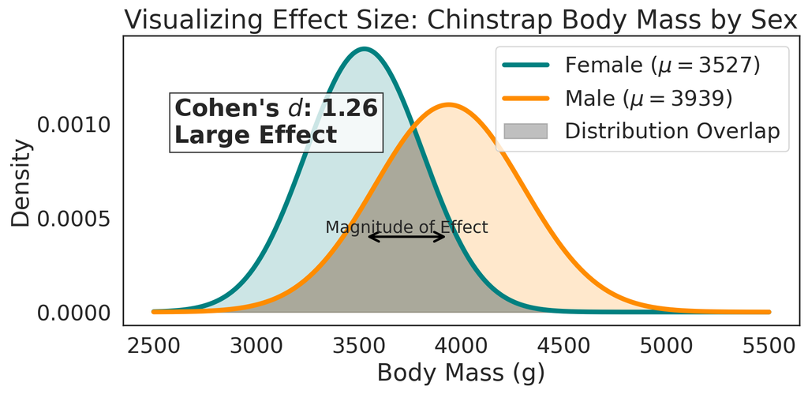

## Statistical Significance and Decision Rules

- Significance compares p-values to a preset alpha (e.g., 0.05)
- A threshold is a decision rule, not a truth statement
- False positives and false negatives are always possible
- Practical importance may differ from statistical significance
- Report effect size alongside p-values

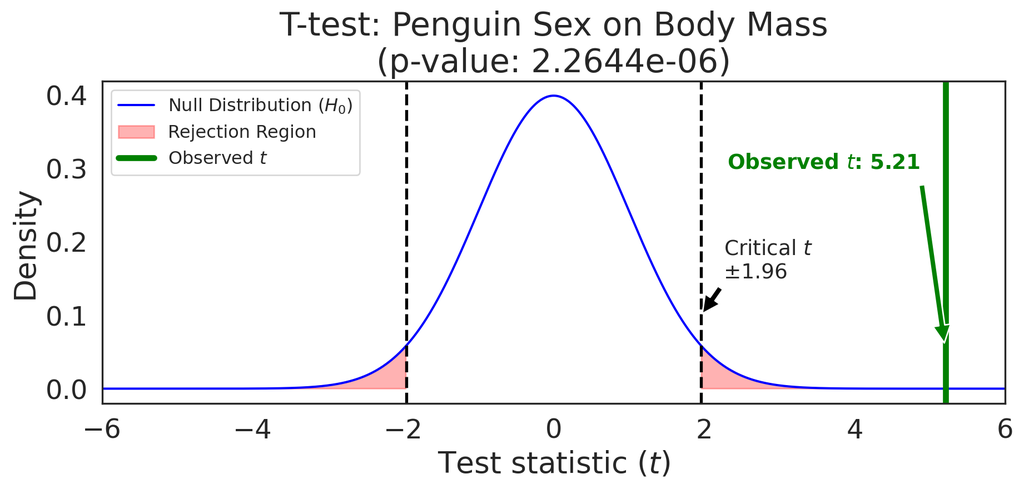

## Type I and II Errors, Statistical Power

- Type I Error (False Positive): Rejecting a true null hypothesis. You claim an effect exists when result due to random noise. 5% risk.
- Type II Error (False Negative): Failing to reject a false null hypothesis. You miss a real difference. Increasing **sample size** reduces this risk and increase **statistical power**.

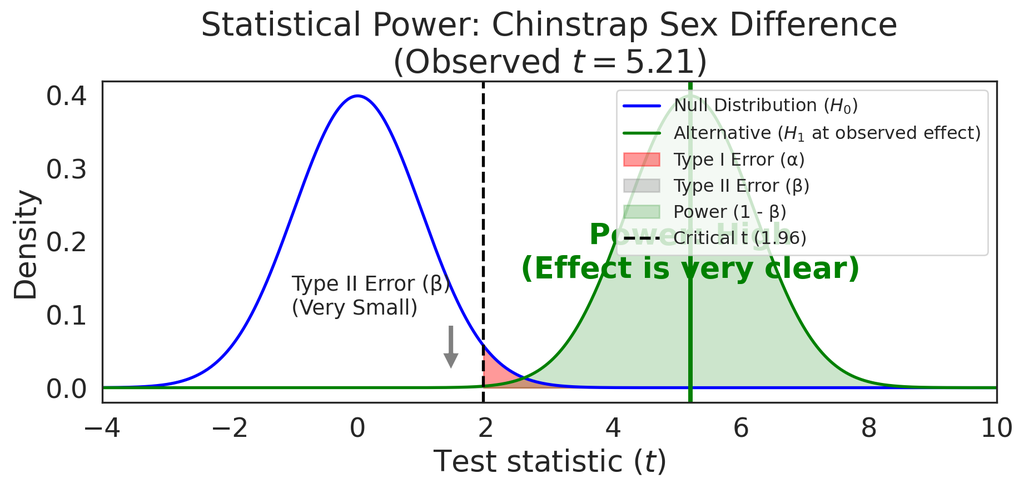

## P-values and the t Distribution

- P-values quantify how extreme data are under the null
- The t distribution depends on degrees of freedom
- Small samples produce heavier tails than normal
- Larger samples make t approximate normal closely
- This affects how evidence is judged

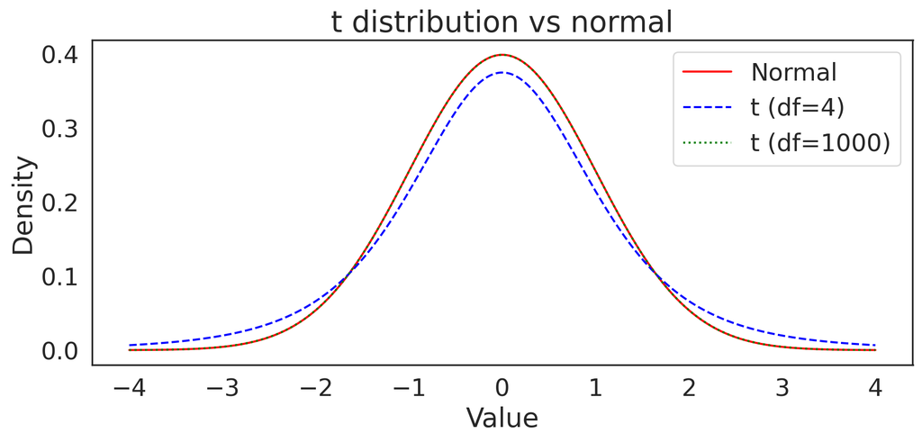

## Comparing Paired Observations

- Paired designs compare two measures on the same penguin
- Use paired t-tests or sign tests on difference scores
- Visualize within-individual differences with connecting lines
- Controls individual variability by pairing observations
- Example uses bill length with small measurement noise

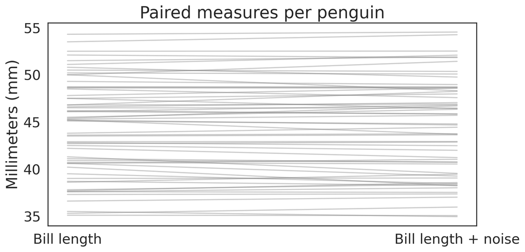

## Comparing More Than Two Means

- Use ANOVA to test differences across 3+ species
- Controls Type I error compared with multiple t-tests
- Follow significant results with post-hoc comparisons
- Interpret effect sizes (e.g., eta-squared)
- Transform multinomial to dummy for linear regression

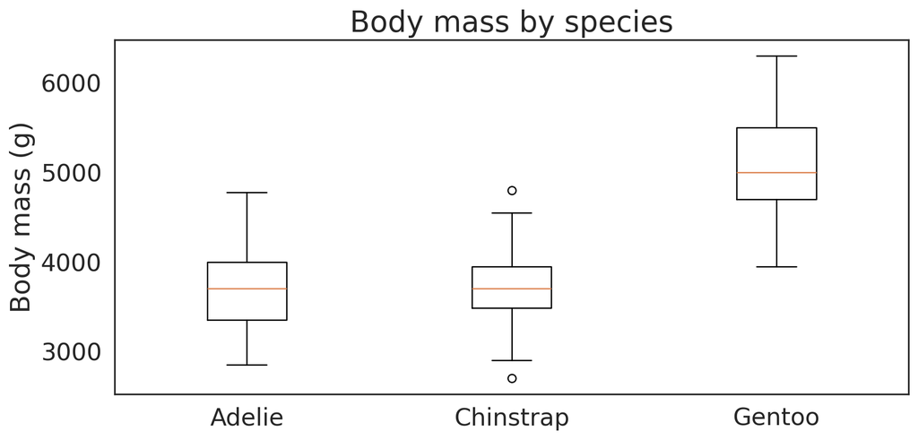

## The t-test as Linear Model

- A two-group t-test equals a linear model with a dummy variable
- Intercept equals the mean of the reference group
- The coefficient equals the mean difference between groups
- Same t-statistic, same p-value (for two-tailed tests)
- Useful for survey experiments!

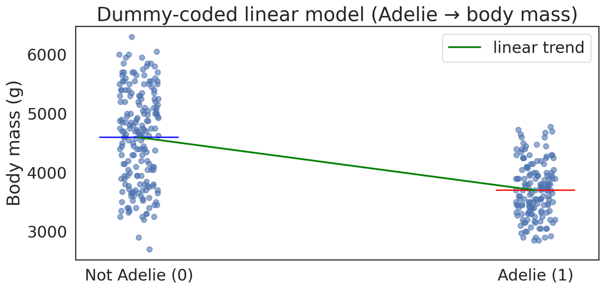

## Categorical data, Counts

- Categorical data are counts by category
- Use penguin species counts as a concrete example
- Good first step: visualize the frequency distribution
- Large deviations suggest non-random patterns
- Sets up a formal chi-squared test

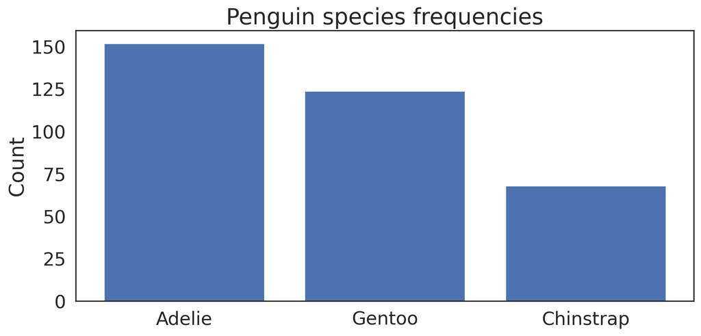

## Contingency Tables and Two-Way Tests

- Two categorical variables form a contingency table
- Example: species by island
- Chi-squared tests independence between variables
- Expected counts come from row/column margins
- Heatmaps highlight influential cells

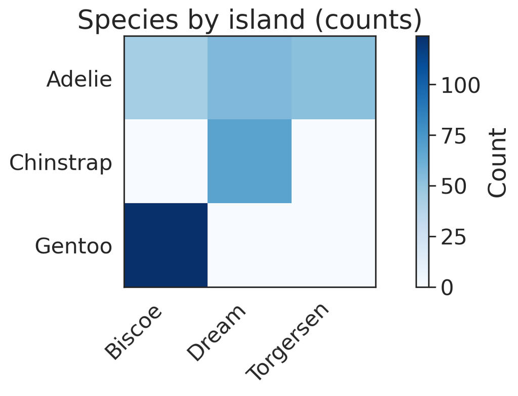

## Pearson’s Chi-Squared Test

- Tests whether observed species counts differ from expectation
- Uses the chi-squared distribution under the null
- Larger values indicate bigger deviations
- Degrees of freedom depend on number of categories
- Visualize the reference distribution to interpret p-values

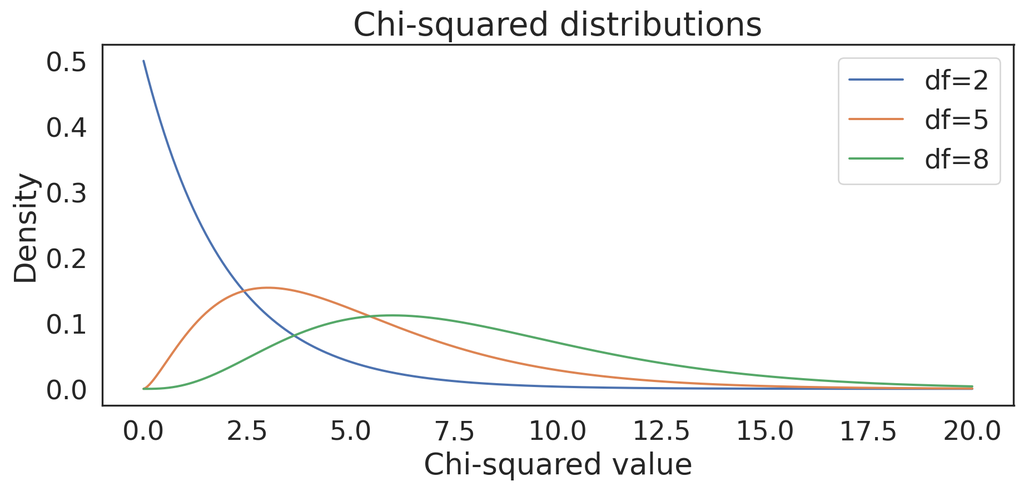

## Covariance and Correlation, Pearson’s r

- Covariance captures joint variability of two measures
- Correlation standardizes covariance to -1 to 1
- Example: bill length vs body mass
- Correlation summarizes linear association only
- Always inspect the data visually

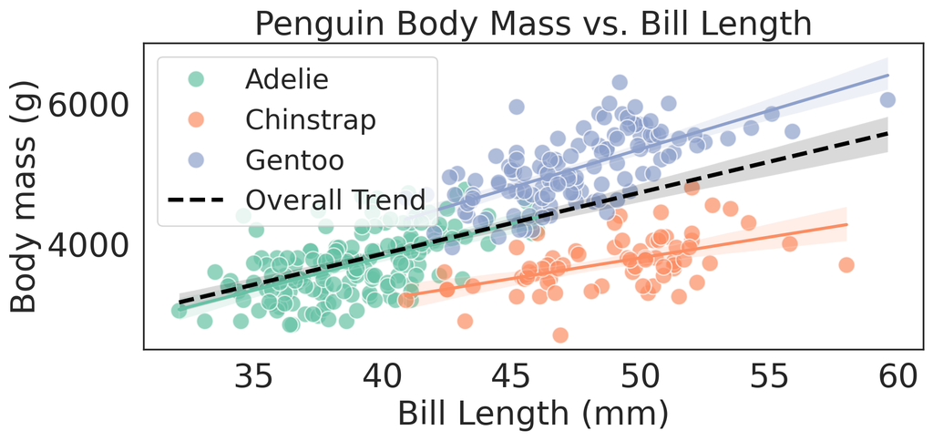

## Hypothesis Testing for Correlations

- Test whether an observed correlation differs from zero
- Use bill length vs body mass as the example
- Permutation tests are intuitive and assumption-light
- P-value is the tail area beyond the observed correlation
- Always report the effect size along with significance

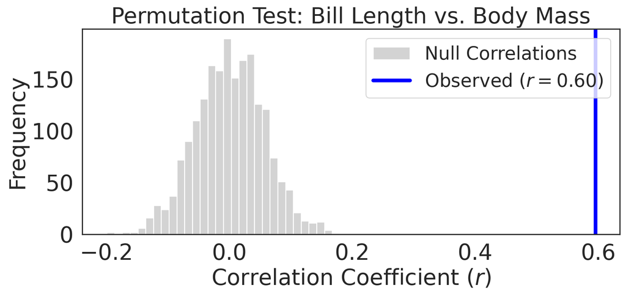

## Robust Correlations and Outliers

- Outliers can inflate or reverse correlations
- Use penguin body mass vs bill length as an example
- Highlight extreme points that may dominate the fit
- Consider Spearman’s rho or trimmed correlation
- Report sensitivity of results to outliers

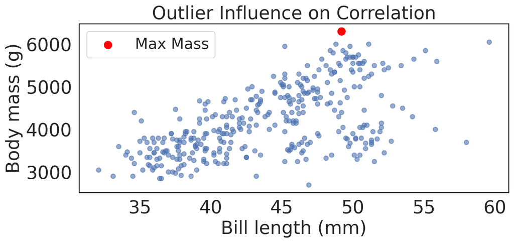

Intro, Computer Lab 2

## Data analysis project

- Download sample [dataset](https://github.com/cca-cce/osm-comm/raw/refs/heads/main/csv/cod-260120.xlsx) and analyze model
- Perform descriptive statistics and data transformations
- `Perform bivariate analyses and hypothesis testing`
- Perform multivariate analysis, multiple regression

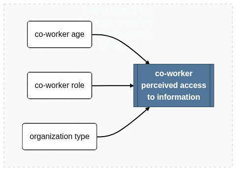

## Dependent variable: Information access

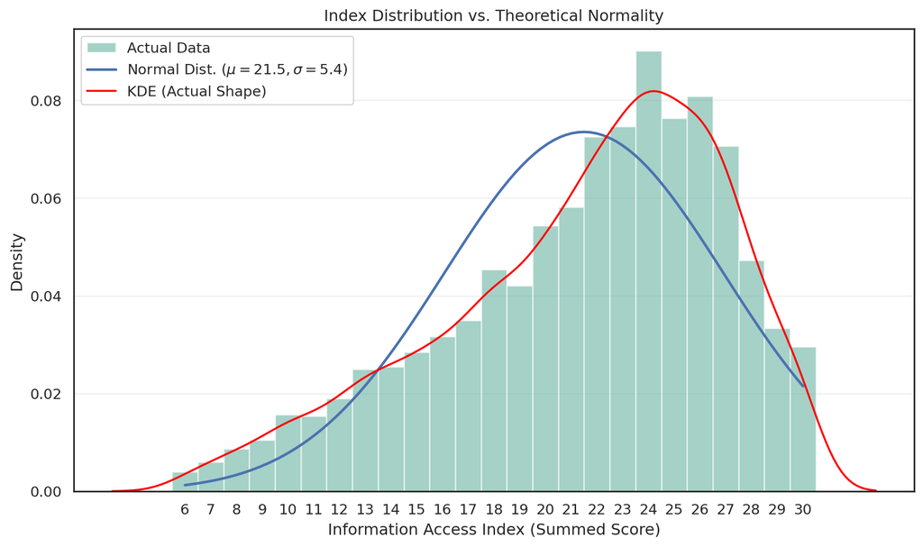

## Independent variable: Organization type

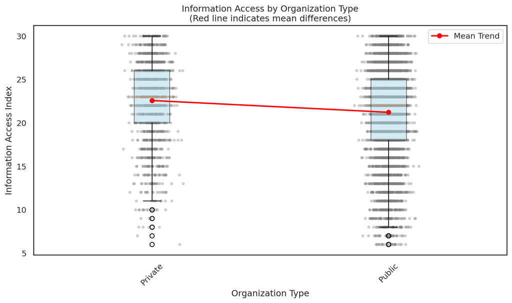

## Next steps

**Lecture lab 2, feb 6**

- Lecture notes: https://cca-cce.github.io/osm-comm/web/edu/skpm20-lecture-lab2.html
- Lab notebook: https://colab.research.google.com/github/cca-cce/osm-comm/blob/main/jnb/skpm20_labs.ipynb
- Sample assignment: https://colab.research.google.com/github/cca-cce/osm-comm/blob/main/jnb/skpm20_exam.ipynb

**References**

Field, Andy. 2022. “An Adventure in Statistics: The Reality Enigma.”

Poldrack, R. 2023. *Statistical Thinking: Analyzing Data in an Uncertain World*. Princeton University Press. https://statsthinking21.github.io/statsthinking21-core-site/.

Van de Ven, Andrew H. 2007. *Engaged Scholarship: A Guide for Organizational and Social Research*. Oxford University Press.